# **CUNEF**

## **Practice III - Retail score analysis**

#### **Machine Learning**</strong>

Pablo Mazariegos Reviriego - pablo.mazariegos@cunef.edu

Mario Sabater Pascual - mario.sabater@cunef.edu

In this Machine Learning practice we will be working with the **Yelp dataset**. The whole practice will be composed by the following notebooks:

1. Data Reading and Problem statement
2. Data selection & variables preparation
3. EDA
4. **Model selection**
5. Best Model and Explainability
6. Variables Relationship (Graphs)

**Creating the prediction Models**

In this notebook after splitting the data between train and test and selecting the metric we will be using to compare our models, We are will test several models on the selected and transformed data set.

- Libraries import and dataset load
- Functions used in this notebook
- Train, Validation and Test split
- Performance Metric Selection
- Models
  - Base Model (Dummy)
  - Decision Tree Classifier
  - Random Forest Classifier
  - Logistic Regression + Lasso
  - Support Vector Machine with Stochastic Gradient Descent
  - XGBoost
  - LightGBM
- Score Summary

## **Libraries import and dataset load**

```python
import numpy as np
import pandas as pd
import matplotlib.pyplot as plt
import matplotlib.cm as cm
from matplotlib.patches import Ellipse
import joblib

from sklearn.datasets import make_blobs
from sklearn.datasets import make_moons
from sklearn.metrics import fbeta_score
from sklearn.metrics import silhouette_samples, silhouette_score
from sklearn.model_selection import GridSearchCV
from sklearn.metrics import confusion_matrix, roc_curve, auc

import networkx as nx
import warnings
warnings.filterwarnings('ignore')
```

**Data Read**

```python
pd.set_option('display.max_columns', 500)
restaurants = pd.read_csv('../data/processed/restaurants_models.csv')
restaurants.head(3)
```

|  | stars | review_count | is_open | restaurants | food | bars | sandwiches | american (traditional) | pizza | coffee & tea | breakfast & brunch | american (new) | fast food | burgers | mexican | italian | specialty food | seafood | desserts | bakeries | salad | chinese | cafes | chicken wings | ice cream & frozen yogurt | beer | sports bars | cocktail bars | juice bars & smoothies | … |
| --- | --- | --- | --- | --- | --- | --- | --- | --- | --- | --- | --- | --- | --- | --- | --- | --- | --- | --- | --- | --- | --- | --- | --- | --- | --- | --- | --- | --- | --- | --- |
| 0 | 1.0 | 0.009917 | 1.0 | 1.0 | 1.0 | 0.0 | 0.0 | 0.0 | 0.0 | 1.0 | 0.0 | 0.0 | 0.0 | 0.0 | 0.0 | 0.0 | 0.0 | 0.0 | 0.0 | 1.0 | 0.0 | 0.0 | 0.0 | 0.0 | 0.0 | 0.0 | 0.0 | 0.0 | 0.0 | … |
| 1 | 1.0 | 0.001058 | 1.0 | 0.0 | 1.0 | 0.0 | 0.0 | 0.0 | 0.0 | 0.0 | 0.0 | 0.0 | 0.0 | 0.0 | 0.0 | 0.0 | 0.0 | 0.0 | 0.0 | 0.0 | 0.0 | 0.0 | 0.0 | 0.0 | 0.0 | 0.0 | 0.0 | 0.0 | 0.0 | … |
| 2 | 0.0 | 0.000132 | 1.0 | 1.0 | 1.0 | 0.0 | 1.0 | 0.0 | 0.0 | 0.0 | 0.0 | 0.0 | 1.0 | 1.0 | 0.0 | 0.0 | 0.0 | 0.0 | 0.0 | 0.0 | 0.0 | 0.0 | 0.0 | 0.0 | 1.0 | 0.0 | 0.0 | 0.0 | 0.0 | … |

## **Functions used in this notebook**

```python
def analyze_train_test_performance(clf, X_train, X_test, y_train, y_test):

    '''Analyze Train and Test Performance'''

    # get predictions
    y_pred_train = clf.predict(X_train)
    y_pred_test  = clf.predict(X_test)

    # get confusion matrices
    confmat_train = confusion_matrix(y_train, y_pred_train)
    confmat_test  = confusion_matrix(y_test, y_pred_test)

    # Plot confusion matrices and provide metrics
    print_performance_metrics(confmat_train, confmat_test)
    plot_confusion_matrix(confmat_train, confmat_test)

    # Plot ROC curve
    y_prob = clf.predict_proba(X_test)[:,1]
    plot_roc_curve(y_test,y_prob)
```

```python
# Para f0.5 score:

from sklearn.metrics import fbeta_score

def hyper_parameters_search(clf, X, y, param_grid, scorer = fbeta_score, beta=0.5, cv=5):

    grid = GridSearchCV(clf, param_grid = param_grid, scoring = scorer, cv = cv)
    grid.fit(X, y)

    print("best mean cross-validation score: {:.3f}".format(grid.best_score_))
    print("best parameters: {}".format(grid.best_params_))

    return grid
```

```python
def print_performance_metrics(confmat_train, *confmat_test):
    '''Print performance metrics'''

    if not confmat_test:
        acc, sen, esp, ppv, fsc = get_metrics(confmat_train)
        print('ACC: %2.2f' %(100*acc))
        print('SEN: %2.2f' %(100*sen))
        print('ESP: %2.2f' %(100*esp))
        print('PPV: %2.2f' %(100*ppv))
        print('F0.5: %2.2f' %(100*fsc))
    else:
        acc_train, sen_train, esp_train, ppv_train, fsc_train = get_metrics(confmat_train)
        acc_test, sen_test, esp_test, ppv_test, fsc_test = get_metrics(confmat_test[0])

        print('PERFORMANCE METRICS')
        print('\tTRAIN\tTEST')
        print('ACC:\t%2.2f\t%2.2f' %(100*acc_train, 100*acc_test))
        print('SEN:\t%2.2f\t%2.2f' %(100*sen_train, 100*sen_test))
        print('ESP:\t%2.2f\t%2.2f' %(100*esp_train, 100*esp_test))
        print('PPV:\t%2.2f\t%2.2f' %(100*ppv_train, 100*ppv_test))
        print('F0.5:\t%2.2f\t%2.2f'  %(100*fsc_train, 100*fsc_test))
```

```python
def get_metrics(confmat):
    '''Unravel confusion matrix and calculate performance metrics'''
    tn, fp, fn, tp = confmat.ravel()

    acc = (tp+tn)/(tn + fp + fn + tp)
    sen = tp/(tp+fn)
    esp = tn/(tn+fp)
    ppv = tp/(tp+fp)
    fsc = 2*(sen*ppv)/(sen+ppv)

    return acc, sen, esp, ppv, fsc
```

```python
def plot_confusion_matrix(confmat_train, *confmat_test):
    ''' Plot confusion matrix
        - A single confusion matrix
        - Comparing two confusion matrices, if provided
    '''

    if not confmat_test:
        fig, ax = plt.subplots(figsize=(3, 3))
        ax.matshow(confmat_train, cmap=plt.cm.Blues, alpha=0.5)
        for i in range(confmat_train.shape[0]):
            for j in range(confmat_train.shape[1]):
                ax.text(x=j, y=i, s=confmat_train[i, j], va='center', ha='center')

        plt.xlabel('predicted label')
        plt.ylabel('true label')

        plt.tight_layout()
        plt.show()

    else:
        fig, ax = plt.subplots(1,2,figsize=(6, 6))
        ax[0].matshow(confmat_train, cmap=plt.cm.Blues, alpha=0.5)
        for i in range(confmat_train.shape[0]):
            for j in range(confmat_train.shape[1]):
                ax[0].text(x=j, y=i, s=confmat_train[i, j], va='center', ha='center')

        ax[1].matshow(confmat_test[0], cmap=plt.cm.Blues, alpha=0.5)
        for i in range(confmat_test[0].shape[0]):
            for j in range(confmat_test[0].shape[1]):
                ax[1].text(x=j, y=i, s=confmat_test[0][i, j], va='center', ha='center')

        ax[0].set_xlabel('predicted label')
        ax[0].set_ylabel('true label')
        ax[0].set_title('TRAIN')

        ax[1].set_xlabel('predicted label')
        ax[1].set_ylabel('true label')
        ax[1].set_title('TEST')

        plt.tight_layout()
        plt.show()
```

```python
def plot_roc_curve(y,y_prob):

    '''Plot ROC-AUC Curve and target probability'''

    ejex, ejey, _ = roc_curve(y, y_prob)
    roc_auc = auc(ejex, ejey)

    plt.figure(figsize = (12,4))

    # ROC-AUC CURVE
    plt.subplot(1,2,1)
    plt.plot(ejex, ejey, color='darkorange',lw=2, label='AUC = %0.2f' % roc_auc)
    plt.plot([0, 1], [0, 1], color=(0.6, 0.6, 0.6), linestyle='--')
    plt.plot([0, 0, 1],[0, 1, 1],lw=2, linestyle=':',color='black',label='Perfect classifier')
    plt.xlim([-0.05, 1.05])
    plt.ylim([-0.05, 1.05])
    plt.xlabel('FPR (1-ESP)')
    plt.ylabel('SEN')
    plt.legend(loc="lower right")

    # PROB DENSITY
    idx_0 = (y==0)
    idx_1 = (y==1)

    plt.subplot(1,2,2)
    plt.hist(y_prob[idx_0],density=1,bins = 20, label='y=0',alpha=0.5)
    plt.hist(y_prob[idx_1],density=1,bins = 20, facecolor='red',label='y=1',alpha=0.5)
    plt.legend()
    plt.xlabel('target probability')

    plt.show()
```

## **Train, Validation and Test split**

```python
seed = 12345
```

Before splitting into train and test, we will separate the between the target variable and all the rest of the variables, becoming X and Y respectively.

```python
y = restaurants['stars'] #stars would be our y variable, the one we want to predict
X = restaurants.drop('stars', axis = 1) #X would be the whole dataset without the stars variable.
```

Now we separate both into train + validation (x and y) and test (x_test, y_test)

```python
from sklearn.model_selection import train_test_split

X_train, X_test, y_train, y_test = train_test_split(
    X, y, stratify=y, test_size=0.30, random_state=seed)
```

```python
y.sum()/len(y)
```

```
0.4766707193111833
```

```python
y_test.sum()/len(y_test)
```

```
0.47668083975551423
```

We observe that both train and test have the same proportion of "stars1, hence we continue with the spit

## **Performance Metric Selection**

**Accuracy:** It’s the ratio of the correctly labeled subjects to the whole pool of subjects in this case Accuracy answers the following question: How many restaurants did we correctly label out of all the restaurants?

**Sensitivity:** Recall or sensitivity is the ratio of the correctly labeled stars( if its more than 4 would be a successful restaurant) by our program to all who are stars in reality. Recall answers the following question: Of all the succesful restaurantes that got more than 4 stars, how many of those we correctly predict?

**Specificity** is the correctly labeled as no stars( if its more than 4 would be a successful restaurant) by the program to all who are no stars restaurants in reality. Specifity answers the following question: of all the succesful restaurants that we declared unsuccesful, how many of those did we correctly predict?

**F0.5-score** is the weighted harmonic mean of the precision and recall (given a threshold value). Unlike the F1 score, which gives equal weight to precision and recall, the F0. 5 score gives more weight to precision than to recall.

**Precision** or Positive Predictive Value is the ratio of the correctly labeled as stars( if its more than 4 would be a successful restaurant) by our program to all stars labeled. Precision answers the following: How many of those restaurants label success are actually a success?

*stars( if its more than 4 would be a successful restaurant)

[figure not shown]

Putting ourselves in the selling point of view of the model for predicting what kind of restaurant would be successful. We consider that it is a 'class labels' problem, and within the two possibilities, being a successful restaurant is more important than not being a successful restaurant. Failure would be in the case that an investor makes the investment and does not obtain the predicted results. In conclusion, the necessary metric for this problem is 'f0.5'.

## **Models**

### Base Model (Dummy)

The frist model we will work with is a dummy model. A dummy model is said to be a very simple model with a low capacity of prediction. In this case we will predict only for the class 0. Note that, as we are imputing the same class for all the dataset, the model should be a perfect classifier for class 0.

```python
from sklearn.dummy import DummyClassifier

# Initialize Estimator
dummy_clf = DummyClassifier(strategy='most_frequent').fit(X_train, y_train)

# Check for Model Accuracy
y_pred_dummy = dummy_clf.predict(X_test)
y_pred_dummy_prob = dummy_clf.predict_proba(X_test)
```

```python
from sklearn.metrics import fbeta_score
from sklearn.metrics import classification_report

f0_5 = fbeta_score(y_test, y_pred_dummy, beta=0.5, pos_label=1)
print(f"f0.5 para la clase 1: {f0_5:.3f}")

print(classification_report(y_test, y_pred_dummy, labels=[0, 1], target_names=[
    'clase 0', 'clase 1']))
```

```
f0.5 para la clase 1: 0.000
              precision    recall  f1-score   support

     clase 0       0.52      1.00      0.69      7877
     clase 1       0.00      0.00      0.00      7175

    accuracy                           0.52     15052
   macro avg       0.26      0.50      0.34     15052
weighted avg       0.27      0.52      0.36     15052
```

### Decision Tree Classifier

```python
from sklearn.tree import DecisionTreeClassifier
from sklearn.model_selection import GridSearchCV


# Metric for the scoring
scorer = 'recall'

# Decision trees
param_grid = {'max_depth': range(1, 5)}

# Customized function
grid_tree = hyper_parameters_search(DecisionTreeClassifier(random_state = seed),
                                    X_train , y_train, param_grid, scorer = scorer)

# do the plotting
#plot_cv_scoring(grid_tree,'max_depth',scorer, plot_errors = True)

dt =  DecisionTreeClassifier(**grid_tree.best_params_).fit(X_train ,y_train)

joblib.dump(dt, "../models/dt.joblib")
```

```
best mean cross-validation score: 0.615
best parameters: {'max_depth': 4}
```

```
['../models/dt.joblib']
```

```
PERFORMANCE METRICS
	TRAIN	TEST
ACC:	66.35	66.90
SEN:	59.17	59.16
ESP:	72.89	73.95
PPV:	66.53	67.41
F0.5:	62.63	63.02
```

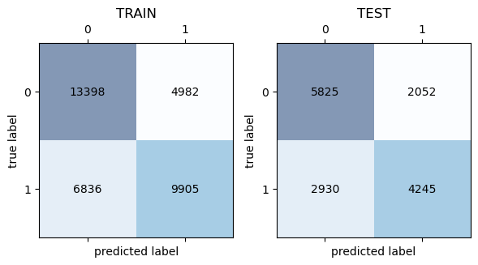

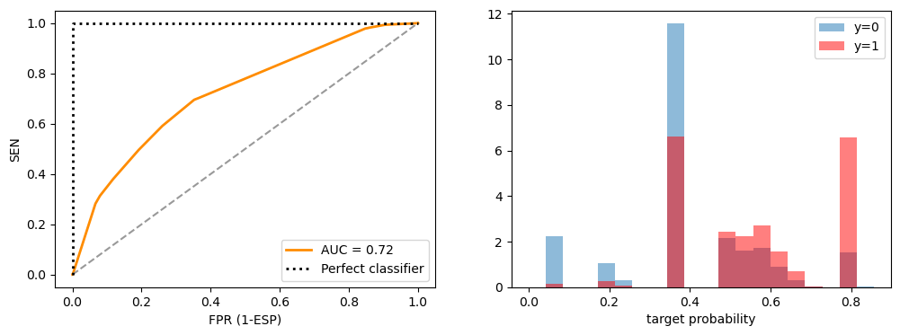

```python
loaded_dt = joblib.load("../models/dt.joblib")
analyze_train_test_performance(loaded_dt,X_train,X_test,y_train,y_test)
```

**Accuracy:** In this case $66.35\%$ in the training set and in the test set $66.90\%$.

**Sensitivity:** In this case $59.17$ in the training set and $59.16$ in the test set.

**Specificity** In this case for the training set $72.89\%$ and for the test set $73.95\%$.

**F0.5-score** In this case for the training set we have $62.63\%$ and for the test set $63.02\%$.

**Precision** In this case we have for the train set $66.53\%$ and for the test set $67.41\%$.

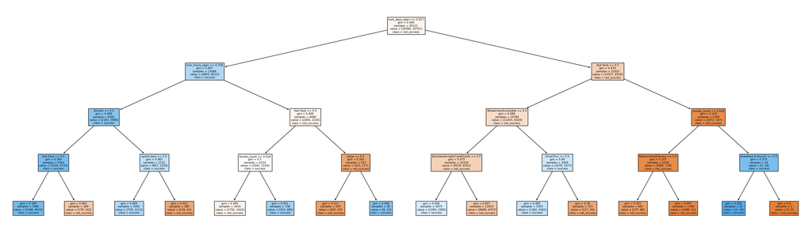

```python
from sklearn.tree import plot_tree

# set plot dimensions
plt.figure(figsize=(35, 10))

feature_names=X.columns

plot_tree(
    dt,
    feature_names=feature_names,
    class_names=['not_success','success'],
    filled=True
)

plt.show()
```

### Random Forest Classifier

A random forest algorithm consists of a set of decision trees. Each tree gets a ranking and the class that gets the most votes is the winner. The fundamental concept of the random forest is simple but very powerful: small classifiers with little capacity together have a lot of capacity. The low correlation between the models makes their joint predictions more powerful. The reason for this wonderful effect is that the trees protect each other from possible individual errors

```python
from sklearn.ensemble import RandomForestClassifier

#we use the separation criterion gini index to choose the important variables.

rf = RandomForestClassifier(n_estimators=15,random_state=seed,
n_jobs=-1,oob_score=True,class_weight='balanced').fit(X_train, y_train)
# do the plotting
#plot_cv_scoring(grid_tree,'max_depth',scorer, plot_errors = True)

joblib.dump(rf, "../models/rf.joblib")
```

```
['../models/rf.joblib']
```

```
PERFORMANCE METRICS
	TRAIN	TEST
ACC:	99.55	71.87
SEN:	99.56	70.47
ESP:	99.54	73.15
PPV:	99.49	70.51
F0.5:	99.53	70.49
```

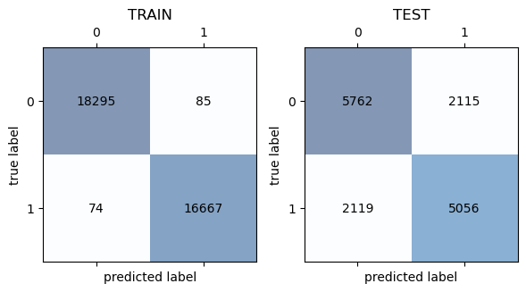

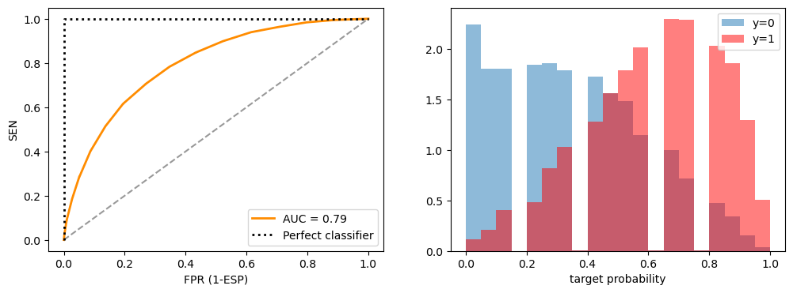

```python
loaded_rf = joblib.load("../models/rf.joblib")
analyze_train_test_performance(loaded_rf,X_train,X_test,y_train,y_test)
```

**Accuracy:** In this case $99.55\%$ in the training set and in the test set $71.87\%$.

**Sensitivity:** In this case $99.56$ in the training set and $70.47$ in the test set.

**Specificity** In this case for the training set $99.54\%$ and for the test set $73.15\%$.

**F0.5-score** In this case for the training set we have $99.53\%$ and for the test set $70.49\%$.

**Precision** In this case we have for the train set $99.49\%$ and for the test set $70.51\%$.

**Feature Importance for Random Forest Classifier**

```python
feature_scores = pd.Series(rf.feature_importances_, index=X.columns).sort_values(
    ascending=False)
feature_scores = pd.DataFrame(feature_scores)
```

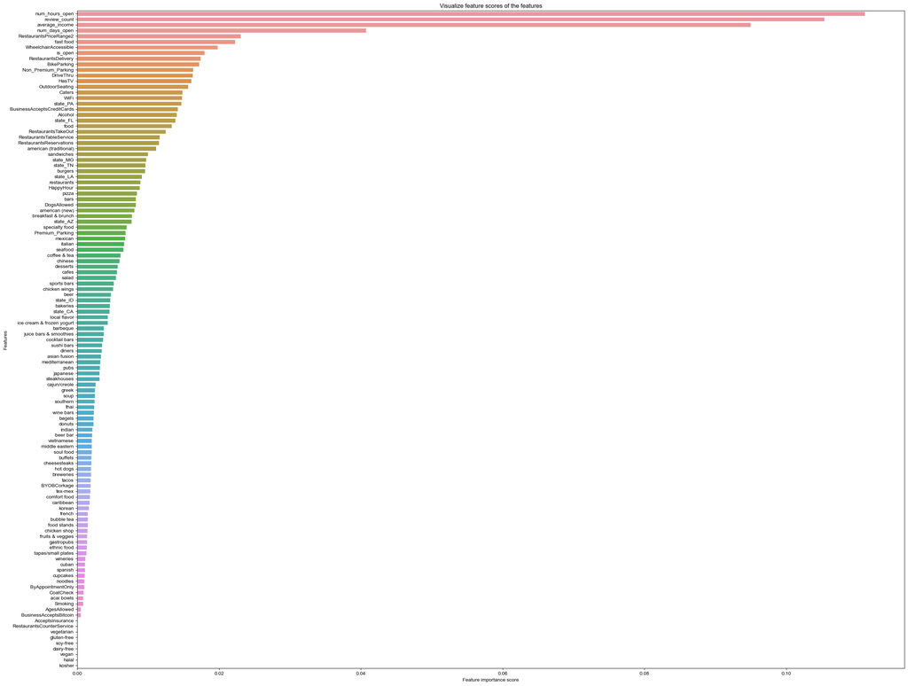

```python
import seaborn as sns

f, ax = plt.subplots(figsize=(30,24))
sns.set(font_scale=1)
ax = sns.barplot(x=feature_scores[0], y=feature_scores.index, data=feature_scores)
ax.set_title("Visualize feature scores of the features")
ax.set_yticklabels(feature_scores.index)
ax.set_xlabel("Feature importance score")
ax.set_ylabel("Features")
plt.show()
```

Feature importance is important to see how the model makes the decisions it makes. Normally, ML models take variables to be more important that others and of course, this is a good information for us. If a model realies on a variable more than the others it means we have to look at it in a deeper way.

### Logistic Regression + Lasso

Logistic + lasso regression In this type of regression we will be using the lasso regularisation, this technique tries to reduce the overfitting (l1). When we do lasso regularisation we are minimizing: $\sum^{n}_{i=1}(y_{i}- \sum_{j} x_{ij} \beta_{j})^{2} + \lambda \sum^{p}_{j=1} |\beta_{j}|$.

The tuning parameter, $\lambda$ controls the strength of the L1 penalty. $\lambda$ is basically the amount of shrinkage:

```python
from sklearn.linear_model import LogisticRegression

# Logistic regression
#we apply a l1 penalty score so we make it lasso
lr = LogisticRegression(penalty='l1', solver='liblinear').fit(X_train,y_train)
#model.predict_proba(X_train)

# save
joblib.dump(lr, "../models/logistic_reg.joblib")
```

```
['../models/logistic_reg.joblib']
```

```
PERFORMANCE METRICS
	TRAIN	TEST
ACC:	71.15	72.15
SEN:	68.28	68.85
ESP:	73.78	75.16
PPV:	70.34	71.63
F0.5:	69.29	70.21
```

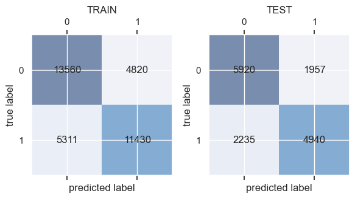

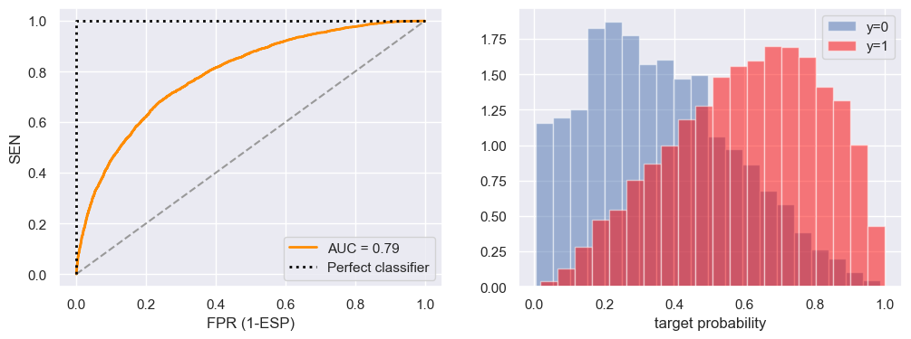

```python
loaded_lr = joblib.load("../models/logistic_reg.joblib")
analyze_train_test_performance(loaded_lr,X_train, X_test ,y_train,y_test)
```

**Accuracy:** In this case $71.15\%$ in the training set and in the test set $72.15\%$.

**Sensitivity:** In this case $68.28$ in the training set and $68.85$ in the test set.

**Specificity** In this case for the training set $73.77\%$ and for the test set $75.16\%$.

**F0.5-score** In this case for the training set we have $69.29\%$ and for the test set $70.21\%$.

**Precision** In this case we have for the train set $70.33\%$ and for the test set $71.63\%$.

**How does the model make the decision for the classification between one class and the other?**

To explain how the algorithm is able to classify one class and another we will use the odds ratio. The odds ratio is the probability of event over the probability of no event, the logistic regression is going to be based on how the prediction changes when one of the features is changed by 1 unit.

```python
log_odds = lr.coef_[0]
pd.DataFrame(log_odds,
             X.columns,
             columns=['coef'])\
            .sort_values(by='coef', ascending=False)
```

|  | coef |
| --- | --- |
| review_count | 14.149850 |
| wineries | 0.790457 |
| acai bowls | 0.750363 |
| tacos | 0.730290 |
| food stands | 0.668140 |
| ... | ... |
| DriveThru | -1.193085 |
| fast food | -1.240681 |
| num_days_open | -1.591783 |
| num_hours_open | -1.618221 |
| AgesAllowed | -1.713019 |

117 rows × 1 columns

Each row corresponds to a predictor or feature (e.g. review_count, wineries) and the value in the 'coef' column is the corresponding coefficient in a linear regression model. The predictors are likely dummy variables with a value of 0 or 1, indicating the presence or absence of a particular feature.

The signs of the coefficients (positive or negative) indicate the direction of the relationship between the predictor and the outcome. Positive coefficients indicate that an increase in the predictor is associated with an increase in the outcome, while negative coefficients indicate that an increase in the predictor is associated with a decrease in the outcome.

### Support Vector Machine with Stochastic Gradient Descent

The objective of the support vector machine algorithm is to find a hyperplane in an N-dimensional space(N — the number of features) that distinctly classifies the data points. Our objective is to find a plane that has the maximum margin, i.e the maximum distance between data points of both classes. Maximizing the margin distance provides some reinforcement so that future data points can be classified with more confidence. link-SVM

```python
from sklearn.linear_model import SGDClassifier
from sklearn.calibration import CalibratedClassifierCV
from sklearn.feature_selection import SelectFromModel
from sklearn.pipeline import make_pipeline

svc=SGDClassifier(random_state = seed, loss="hinge").fit(X_train,y_train)
calibrator = CalibratedClassifierCV(svc, cv='prefit').fit(X_train, y_train)
#scores = cross_val_score(svc, X, y, cv=10, scoring='accuracy')
#print(scores.mean())


joblib.dump(calibrator, "../models/calibrator.joblib")
```

```
['../models/calibrator.joblib']
```

```
PERFORMANCE METRICS
	TRAIN	TEST
ACC:	70.56	71.24
SEN:	67.34	67.60
ESP:	73.50	74.56
PPV:	69.83	70.76
F0.5:	68.56	69.14
```

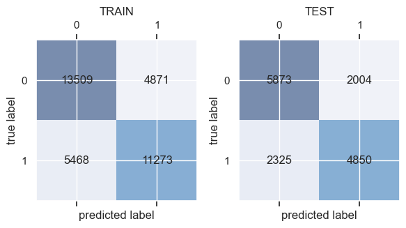

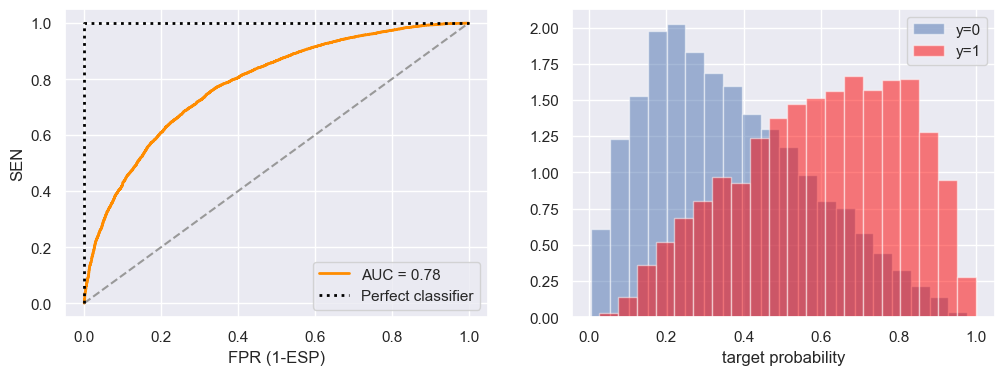

```python
loaded_c = joblib.load("../models/calibrator.joblib")
analyze_train_test_performance(loaded_c,X_train,X_test,y_train,y_test)
```

**Accuracy:** In this case $70.56\%$ in the training set and in the test set $71.24\%$.

**Sensitivity:** In this case $67.34$ in the training set and $67.60$ in the test set.

**Specificity** In this case for the training set $73.50\%$ and for the test set $74.56\%$.

**F0.5-score** In this case for the training set we have $68.56\%$ and for the test set $69.14\%$.

**Precision** In this case we have for the train set $69.83\%$ and for the test set $70.76\%$.

## XGBoost

```python
from xgboost import XGBClassifier
#we use a classifier instead of a regressor because we want to classify wether is a good restaurant or not

xgb = XGBClassifier(random_state = seed, n_jobs=-1).fit(X_train ,y_train)

joblib.dump(xgb, "../models/xgb.joblib")
```

```
['../models/xgb.joblib']
```

```
PERFORMANCE METRICS
	TRAIN	TEST
ACC:	81.19	73.76
SEN:	79.05	71.41
ESP:	83.13	75.90
PPV:	81.02	72.97
F0.5:	80.02	72.18
```

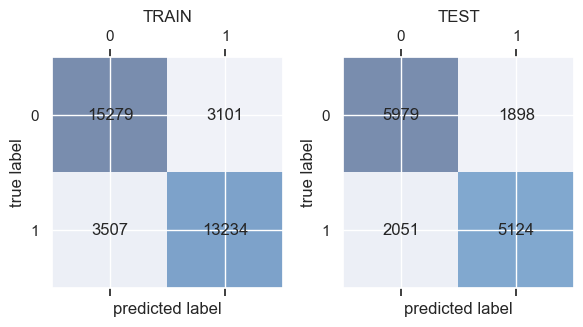

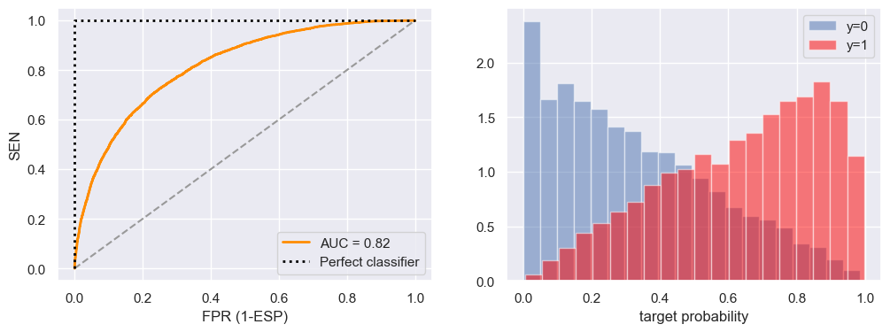

```python
loaded_xgb = joblib.load("../models/my_xgb.joblib")
analyze_train_test_performance(loaded_xgb,X_train,X_test,y_train,y_test)
```

**Accuracy:** In this case $81.19\%$ in the training set and in the test set $73.76\%$.

**Sensitivity:** In this case $79.05$ in the training set and $71.41$ in the test set.

**Specificity** In this case for the training set $83.13\%$ and for the test set $75.90\%$.

**F0.5-score** In this case for the training set we have $80.02\%$ and for the test set $72.18\%$.

**Precision** In this case we have for the train set $81.02\%$ and for the test set $72.97\%$.

## LightGBM

```python
import lightgbm as lgb

# Decision trees

lgbm=  lgb.LGBMClassifier(random_state = seed, n_estimators = 20).fit(X_train ,y_train)

joblib.dump(lgbm, "../models/lgbm.joblib")
```

```
['../models/lgbm.joblib']
```

```
PERFORMANCE METRICS
	TRAIN	TEST
ACC:	72.35	72.67
SEN:	70.54	71.11
ESP:	73.99	74.10
PPV:	71.19	71.44
F0.5:	70.86	71.27
```

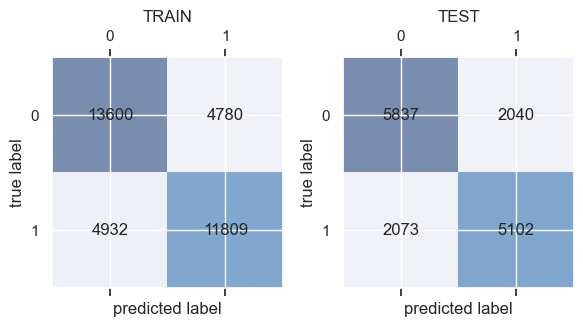

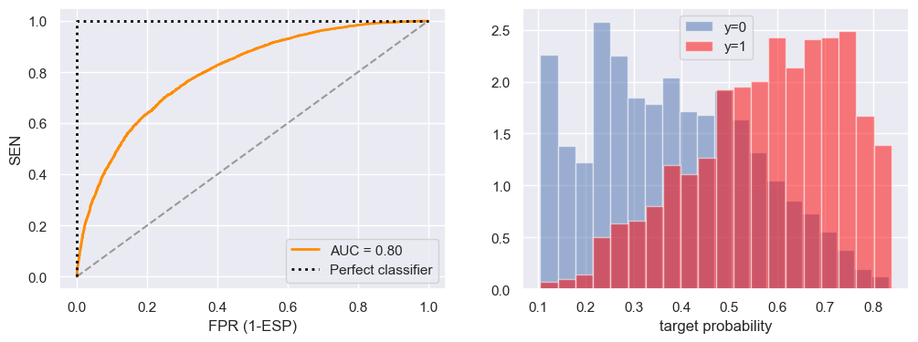

```python
loaded_lgbm = joblib.load("../models/lgbm.joblib")
analyze_train_test_performance(loaded_lgbm,X_train,X_test,y_train,y_test)
```

**Accuracy:** In this case $72.35\%$ in the training set and in the test set $72.67\%$.

**Sensitivity:** In this case $70.54$ in the training set and $71.11$ in the test set.

**Specificity** In this case for the training set $73.99\%$ and for the test set $74.10\%$.

**F0.5-score** In this case for the training set we have $70.86\%$ and for the test set $71.27\%$.

**Precision** In this case we have for the train set $71.19\%$ and for the test set $71.44\%$.

## **Score Summary**

**Ranking Best Models (based on test F0.5 score):**

Despite having a more base F0.5 socre the XGBoost it yields symptoms of overfitting. It is normal to have a lower score or accuracy in the test than in the train, but a decrease of 8 points starts to be significant.

On the other hand the LightGBM model seems yields underfiitig with less than 1% less F0.5-score compared to the XGBoost in test.

The model for logistic regression also seems to have underfitting, but with a lower score than the LightGBM.

As a final model we will use the XGBOOST as it gives us the best f0.5 score and we hope to improve its performance by optimizing the hyperparameters in the next notebook.